# The `ammistability` Package: A Brief Introduction

Ajay, B. C.<sup>1</sup>, Aravind, J.<sup>2</sup>, and Abdul Fiyaz, R.<sup>3</sup>

2023-05-23

1. RRS, ICAR-Directorate of Groundnut Research, Anantapur.
2. ICAR-National Bureau of Plant Genetic Resources, New Delhi.
3. ICAR-Indian Institute of Rice Research, Hyderabad.

[figure not shown]

## Overview

The package `ammistability` (Ajay et al., 2019a) is a collection of functions for the computation of various stability parameters from the results of Additive Main Effects and Multiplicative Interaction (AMMI) analysis computed by the [`AMMI`](https://www.rdocumentation.org/packages/agricolae/versions/1.2-8/topics/AMMI) function of [`agricolae`](https://CRAN.R-project.org/package=agricolae) package.

The goal of this vignette is to introduce the users to these functions and give a primer in computation of various stability parameters/indices from a fitted AMMI model. This document assumes a basic knowledge of `R` programming language.

## Installation

The package can be installed from CRAN as follows:

```r
# Install from CRAN
install.packages('ammistability', dependencies=TRUE)
```

The development version can be installed from github as follows:

```r
# Install development version from Github
devtools::install_github("ajaygpb/ammistability")
```

Then the package can be loaded using the function

```r
library(ammistability)
```

## Version History

The current version of the package is 0.1.4. The previous versions are as follows.

**Table 1.** Version history of `ammistability` `R` package.

| Version | Date |
| --- | --- |
| 0.1.0 | 2018-08-13 |
| 0.1.1 | 2018-12-07 |
| 0.1.2 | 2021-02-23 |
| 0.1.3 | 2022-07-18 |

To know detailed history of changes use `news(package='ammistability')`.

## AMMI model

The difference in response of genotypes to different environmental conditions is known as Genotype-Environment Interaction (GEI). Understanding the nature and structure of this interaction is critical for plant breeders to select for genotypes with wide or specific adaptability. One of the most popular techniques to achieve this is by fitting the Additive Main Effects and Multiplicative Interaction (AMMI) model to the results of multi environment trials (Gauch, 1988, 1992).

The AMMI equation is described as follows.

$$Y_{ij} = \mu + \alpha_{i} + \beta_{j} +
\sum_{n=1}^{N}\lambda_{n}\gamma_{in}\delta_{jn} + \rho_{ij}$$

Where, $Y_{ij}$ is the yield of the $i$th genotype in the $j$th environment, $\mu$ is the grand mean, $\alpha_{i}$ is the genotype deviation from the grand mean, $\beta_{j}$ is the environment deviation, $N$ is the total number of interaction principal components (IPCs), $\lambda_{n}$ is the is the singular value for $n$th IPC and correspondingly $\lambda_{n}^{2}$ is its eigen value, $\gamma_{in}$ is the eigenvector value for $i$th genotype, $\delta_{jn}$ is the eigenvector value for the $j$th environment and $\rho_{ij}$ is the residual.

## AMMI stability parameters

Although the AMMI model can aid in determining genotypes with wide or specific adaptability, it fails to rank genotypes according to their stability. Several measures have been developed over the years to indicate the stability of genotypes from the results of AMMI analysis (Table 1.).

The details about AMMI stability parameters/indices implemented in `ammistability` are described in Table 1.

**Table 1 :** AMMI stability parameters/indices implemented in `ammistability`.

[output not shown]

Where, $N$ is the total number of interaction principal components (IPCs); $N'$ is the number of significant IPCAs (number of IPC that were retained in the AMMI model via F tests); $\lambda_{n}$ is the is the singular value for $n$th IPC and correspondingly $\lambda_{n}^{2}$ is its eigen value; $\gamma_{in}$ is the eigenvector value for $i$th genotype; $\delta_{jn}$ is the eigenvector value for the $j$th environment; $SSIPC_{1}$, $SSIPC_{2}$, $\cdots$, $SSIPC_{n}$ are the sum of squares of the 1st, 2th, …, and $n$th IPC; $PC_{1}$, $PC_{2}$, $\cdots$, $PC_{n}$ are the scores of 1st, 2th, …, and $n$th IPC; $\theta_{n}$ is the percentage sum of squares explained by $n$th principal component interaction effect; and $E$ is the number of environments.

#### AMMI model from `agricolae::AMMI`

```r
library(agricolae)
data(plrv)

# AMMI model
model <- with(plrv, AMMI(Locality, Genotype, Rep, Yield, console = FALSE))

# ANOVA
model$ANOVA
```

|  | Df | Sum Sq | Mean Sq | F value | Pr(>F) |
| --- | --- | --- | --- | --- | --- |
| ENV | 5 | 122284.346 | 24456.86916 | 257.038177 | 9.080292e-12 |
| REP(ENV) | 12 | 1141.785 | 95.14878 | 2.569402 | 2.888739e-03 |
| GEN | 27 | 17533.281 | 649.38078 | 17.535906 | 2.690389e-48 |
| ENV:GEN | 135 | 23761.795 | 176.01330 | 4.753071 | 1.177739e-30 |
| Residuals | 324 | 11998.204 | 37.03149 | NA | NA |

```r
# IPC F test
model$analysis
```

|  | percent | acum | Df | Sum.Sq | Mean.Sq | F.value | Pr.F |
| --- | --- | --- | --- | --- | --- | --- | --- |
| PC1 | 56.3 | 56.3 | 31 | 13368.5954 | 431.24501 | 11.65 | 0.0000 |
| PC2 | 27.1 | 83.3 | 29 | 6427.5799 | 221.64069 | 5.99 | 0.0000 |
| PC3 | 9.4 | 92.7 | 27 | 2241.9398 | 83.03481 | 2.24 | 0.0005 |
| PC4 | 4.3 | 97.1 | 25 | 1027.5785 | 41.10314 | 1.11 | 0.3286 |
| PC5 | 2.9 | 100.0 | 23 | 696.1012 | 30.26527 | 0.82 | 0.7059 |

```r
# Mean yield and IPC scores
model$biplot
```

|  | type | Yield | PC1 | PC2 | PC3 | PC4 | PC5 |
| --- | --- | --- | --- | --- | --- | --- | --- |
| 102.18 | GEN | 26.31947 | -1.50828851 | 1.258765244 | -0.19220309 | 0.48738861 | -0.04364115 |
| 104.22 | GEN | 31.28887 | 0.32517729 | -1.297024517 | -0.63695749 | -0.44159957 | 0.95312506 |
| 121.31 | GEN | 30.10174 | 0.95604605 | 1.143461054 | -1.28777348 | 2.22246913 | -1.30661916 |
| 141.28 | GEN | 39.75624 | 2.11153737 | 0.817810467 | 1.45527701 | 0.25257620 | -0.25996142 |
| 157.26 | GEN | 36.95181 | 1.05139017 | 2.461179974 | -1.97208942 | -1.96538800 | -0.59719268 |
| 163.9 | GEN | 21.41747 | -2.12407441 | -0.284381234 | -0.21791137 | -0.50743629 | 0.18563390 |
| 221.19 | GEN | 22.98480 | -0.84981828 | 0.347983673 | -0.82400783 | -0.11451944 | -0.57504816 |
| 233.11 | GEN | 28.66655 | 0.07554203 | -1.046497338 | 1.04040485 | 0.22868362 | 0.65754266 |
| 235.6 | GEN | 38.63477 | 1.20102029 | -2.816581184 | 0.80975361 | 1.02013062 | -0.40273415 |
| 241.2 | GEN | 26.34039 | -0.79948495 | 0.220768053 | -0.98538801 | 0.30004421 | 0.07555258 |

[output cut: 24 more lines]

```r
# G*E matrix (deviations from mean)
array(model$genXenv, dim(model$genXenv), dimnames(model$genXenv))
```

```
         ENV
GEN              Ayac      Hyo-02       LM-02       LM-03        SR-02       SR-03
  102.18    5.5726162 -12.4918224   1.7425251  -2.7070438   2.91734869   4.9663762
  104.22   -2.8712076   7.1684102   3.9336218  -4.0358373   0.47881580  -4.6738028
  121.31    0.3255230  -3.8666836   4.3182811  10.4366135 -11.88343843   0.6697043
  141.28   -0.9451837   5.6454825  -9.7806639  14.6463104  -4.80337115  -4.7625741
  157.26  -10.3149711 -10.6241677   4.2336365  16.8683612   2.71710210  -2.8799609
  163.9     3.0874931  -6.9416721   3.4963790 -12.5533271   7.01688164   5.8942454
  221.19   -0.6041752  -6.0090018   4.0648518  -2.6974743   1.27671246   3.9690870
  233.11    2.5837535   6.8277609  -3.4440645  -4.4985717   0.19989490  -1.6687730
  235.6    -1.7541523  19.8225025  -2.2394463  -5.6643239  -8.11400542  -2.0505746
  241.2     1.0710975  -5.3831118   5.4253097  -3.2588271   0.46433086   1.6812008
  255.7     2.4443155   1.3860497  -1.8857757 -12.9626594   4.31373929   6.7043306
  314.12   -3.8812099   6.2098482   2.3577759   5.9071782  -3.92419060  -6.6694018
  317.6    -1.7450319   3.0388540   3.0448064   5.5211634  -4.79271565  -5.0670763
  319.20   -6.0155949   2.8477540  -9.7697504  24.8850017  -1.82949467 -10.1179157
  320.16   10.9481796 -10.2982108   4.9608280  -6.2233088   2.99984918  -2.3873373
  342.15    0.8508002  -0.3338618  -2.4575390 -10.3783871   7.29753151   5.0214562
  346.2     4.7000495  -6.2178087  -2.2612391 -14.9700672   9.90123888   8.8478267
  351.26    2.6002030  -0.9918665 -10.8315931  12.7429121  -0.02713985  -3.4925156
  364.21   -0.4533734   3.2864208  -0.1335527  -0.1592533  -4.82292664   2.2826853
  402.7    -1.2134573  -0.0387229  -0.2179557  -0.8774011   1.08032472   1.2672123
  405.2     6.6477681  -8.3071271  -0.6159895  -8.8927189   3.52179705   7.6462704
  406.12   -6.1296667  12.0703469   1.1195092  -2.2601009  -3.13776595  -1.6623226
  427.7    -3.1340922   4.3967072   4.2792028  -1.0194744   0.76266844  -5.2850119
  450.3    -0.5047010  -1.0720791  -3.2821761  12.8806007  -5.04562407  -2.9760204
  506.2    -1.2991912  -1.5682154   8.3142802  -3.1819279   0.60021498  -2.8651608
  Canchan   1.2929442   5.7152780  -9.3713622   9.0803035  -1.65332869  -5.0638348
  Desiree   9.5767845 -22.3280421   0.2396387 -11.8935722   9.62433886  14.7808522
  Unica   -10.8355195  18.0569790   4.7604622  -4.7341684  -5.13878822  -2.1089651
```

#### `AMGE.AMMI()`

```r
# With default n (N') and default ssi.method (farshadfar)
AMGE.AMMI(model)
```

|  | AMGE | SSI | rAMGE | rY | means |
| --- | --- | --- | --- | --- | --- |
| 102.18 | 1.598721e-14 | 48 | 25 | 23 | 26.31947 |
| 104.22 | -8.881784e-15 | 20 | 7 | 13 | 31.28887 |
| 121.31 | 1.643130e-14 | 41 | 26 | 15 | 30.10174 |
| 141.28 | -4.440892e-15 | 11 | 10 | 1 | 39.75624 |
| 157.26 | 3.241851e-14 | 33 | 28 | 5 | 36.95181 |
| 163.9 | 3.108624e-15 | 45 | 18 | 27 | 21.41747 |
| 221.19 | 8.881784e-15 | 48 | 22 | 26 | 22.98480 |
| 233.11 | -1.476597e-14 | 22 | 5 | 17 | 28.66655 |
| 235.6 | -2.975398e-14 | 5 | 1 | 4 | 38.63477 |
| 241.2 | 7.105427e-15 | 42 | 20 | 22 | 26.34039 |

[output cut: 18 more lines]

```r
# With n = 4 and default ssi.method (farshadfar)
AMGE.AMMI(model, n = 4)
```

|  | AMGE | SSI | rAMGE | rY | means |
| --- | --- | --- | --- | --- | --- |
| 102.18 | 1.643130e-14 | 48.0 | 25.0 | 23 | 26.31947 |
| 104.22 | -9.325873e-15 | 20.0 | 7.0 | 13 | 31.28887 |
| 121.31 | 1.731948e-14 | 41.0 | 26.0 | 15 | 30.10174 |
| 141.28 | -4.218847e-15 | 11.5 | 10.5 | 1 | 39.75624 |
| 157.26 | 3.019807e-14 | 33.0 | 28.0 | 5 | 36.95181 |
| 163.9 | 2.664535e-15 | 45.0 | 18.0 | 27 | 21.41747 |
| 221.19 | 8.271162e-15 | 48.0 | 22.0 | 26 | 22.98480 |
| 233.11 | -1.409983e-14 | 22.0 | 5.0 | 17 | 28.66655 |
| 235.6 | -2.797762e-14 | 5.0 | 1.0 | 4 | 38.63477 |
| 241.2 | 6.883383e-15 | 42.0 | 20.0 | 22 | 26.34039 |

[output cut: 18 more lines]

```r
# With default n (N') and ssi.method = "rao"
AMGE.AMMI(model, ssi.method = "rao")
```

|  | AMGE | SSI | rAMGE | rY | means |
| --- | --- | --- | --- | --- | --- |
| 102.18 | 1.598721e-14 | -1.209920 | 25 | 23 | 26.31947 |
| 104.22 | -8.881784e-15 | 4.742740 | 7 | 13 | 31.28887 |
| 121.31 | 1.643130e-14 | -1.030703 | 26 | 15 | 30.10174 |
| 141.28 | -4.440892e-15 | 8.741371 | 10 | 1 | 39.75624 |
| 157.26 | 3.241851e-14 | 0.184960 | 28 | 5 | 36.95181 |
| 163.9 | 3.108624e-15 | -9.937521 | 18 | 27 | 21.41747 |
| 221.19 | 8.881784e-15 | -2.973115 | 22 | 26 | 22.98480 |
| 233.11 | -1.476597e-14 | 3.173817 | 5 | 17 | 28.66655 |
| 235.6 | -2.975398e-14 | 2.370918 | 1 | 4 | 38.63477 |
| 241.2 | 7.105427e-15 | -3.794340 | 20 | 22 | 26.34039 |

[output cut: 18 more lines]

```r
# Changing the ratio of weights for Rao's SSI
AMGE.AMMI(model, ssi.method = "rao", a = 0.43)
```

|  | AMGE | SSI | rAMGE | rY | means |
| --- | --- | --- | --- | --- | --- |
| 102.18 | 1.598721e-14 | -0.03111319 | 25 | 23 | 26.31947 |
| 104.22 | -8.881784e-15 | 2.62088777 | 7 | 13 | 31.28887 |
| 121.31 | 1.643130e-14 | 0.11624442 | 26 | 15 | 30.10174 |
| 141.28 | -4.440892e-15 | 4.49766702 | 10 | 1 | 39.75624 |
| 157.26 | 3.241851e-14 | 0.76628938 | 28 | 5 | 36.95181 |
| 163.9 | 3.108624e-15 | -3.87508635 | 18 | 27 | 21.41747 |
| 221.19 | 8.881784e-15 | -0.85126241 | 22 | 26 | 22.98480 |
| 233.11 | -1.476597e-14 | 1.89751451 | 5 | 17 | 28.66655 |
| 235.6 | -2.975398e-14 | 1.73752955 | 1 | 4 | 38.63477 |
| 241.2 | 7.105427e-15 | -1.14202521 | 20 | 22 | 26.34039 |

[output cut: 18 more lines]

#### `ASI.AMMI()`

```r
# With default ssi.method (farshadfar)
ASI.AMMI(model)
```

|  | ASI | SSI | rASI | rY | means |
| --- | --- | --- | --- | --- | --- |
| 102.18 | 0.91512303 | 43 | 20 | 23 | 26.31947 |
| 104.22 | 0.39631322 | 19 | 6 | 13 | 31.28887 |
| 121.31 | 0.62108102 | 25 | 10 | 15 | 30.10174 |
| 141.28 | 1.20927797 | 26 | 25 | 1 | 39.75624 |
| 157.26 | 0.89176583 | 22 | 17 | 5 | 36.95181 |
| 163.9 | 1.19833464 | 51 | 24 | 27 | 21.41747 |
| 221.19 | 0.48765291 | 34 | 8 | 26 | 22.98480 |
| 233.11 | 0.28677206 | 21 | 4 | 17 | 28.66655 |
| 235.6 | 1.01971997 | 25 | 21 | 4 | 38.63477 |
| 241.2 | 0.45406877 | 29 | 7 | 22 | 26.34039 |

[output cut: 18 more lines]

```r
# With  ssi.method = "rao"
ASI.AMMI(model, ssi.method = "rao")
```

|  | ASI | SSI | rASI | rY | means |
| --- | --- | --- | --- | --- | --- |
| 102.18 | 0.91512303 | 1.3832387 | 20 | 23 | 26.31947 |
| 104.22 | 0.39631322 | 2.2326416 | 6 | 13 | 31.28887 |
| 121.31 | 0.62108102 | 1.7551519 | 10 | 15 | 30.10174 |
| 141.28 | 1.20927797 | 1.6936286 | 25 | 1 | 39.75624 |
| 157.26 | 0.89176583 | 1.7436656 | 17 | 5 | 36.95181 |
| 163.9 | 1.19833464 | 1.0993106 | 24 | 27 | 21.41747 |
| 221.19 | 0.48765291 | 1.7347850 | 8 | 26 | 22.98480 |
| 233.11 | 0.28677206 | 2.6102708 | 4 | 17 | 28.66655 |
| 235.6 | 1.01971997 | 1.7309273 | 21 | 4 | 38.63477 |
| 241.2 | 0.45406877 | 1.9170753 | 7 | 22 | 26.34039 |

[output cut: 18 more lines]

```r
# Changing the ratio of weights for Rao's SSI
ASI.AMMI(model, ssi.method = "rao", a = 0.43)
```

|  | ASI | SSI | rASI | rY | means |
| --- | --- | --- | --- | --- | --- |
| 102.18 | 0.91512303 | 1.0839450 | 20 | 23 | 26.31947 |
| 104.22 | 0.39631322 | 1.5415455 | 6 | 13 | 31.28887 |
| 121.31 | 0.62108102 | 1.3141619 | 10 | 15 | 30.10174 |
| 141.28 | 1.20927797 | 1.4671376 | 25 | 1 | 39.75624 |
| 157.26 | 0.89176583 | 1.4365328 | 17 | 5 | 36.95181 |
| 163.9 | 1.19833464 | 0.8707513 | 24 | 27 | 21.41747 |
| 221.19 | 0.48765291 | 1.1731344 | 8 | 26 | 22.98480 |
| 233.11 | 0.28677206 | 1.6551898 | 4 | 17 | 28.66655 |
| 235.6 | 1.01971997 | 1.4623334 | 21 | 4 | 38.63477 |
| 241.2 | 0.45406877 | 1.3138836 | 7 | 22 | 26.34039 |

[output cut: 18 more lines]

#### `ASTAB.AMMI()`

```r
# With default n (N') and default ssi.method (farshadfar)
ASTAB.AMMI(model)
```

|  | ASTAB | SSI | rASTAB | rY | means |
| --- | --- | --- | --- | --- | --- |
| 102.18 | 3.89636621 | 39 | 16 | 23 | 26.31947 |
| 104.22 | 2.19372771 | 21 | 8 | 13 | 31.28887 |
| 121.31 | 3.87988776 | 29 | 14 | 15 | 30.10174 |
| 141.28 | 7.24523520 | 23 | 22 | 1 | 39.75624 |
| 157.26 | 11.05196482 | 31 | 26 | 5 | 36.95181 |
| 163.9 | 4.64005014 | 46 | 19 | 27 | 21.41747 |
| 221.19 | 1.52227265 | 30 | 4 | 26 | 22.98480 |
| 233.11 | 2.18330553 | 24 | 7 | 17 | 28.66655 |
| 235.6 | 10.03128021 | 28 | 24 | 4 | 38.63477 |
| 241.2 | 1.65890425 | 27 | 5 | 22 | 26.34039 |

[output cut: 18 more lines]

```r
# With n = 4 and default ssi.method (farshadfar)
ASTAB.AMMI(model, n = 4)
```

|  | ASTAB | SSI | rASTAB | rY | means |
| --- | --- | --- | --- | --- | --- |
| 102.18 | 4.1339139 | 36 | 13 | 23 | 26.31947 |
| 104.22 | 2.3887379 | 21 | 8 | 13 | 31.28887 |
| 121.31 | 8.8192568 | 38 | 23 | 15 | 30.10174 |
| 141.28 | 7.3090299 | 22 | 21 | 1 | 39.75624 |
| 157.26 | 14.9147148 | 31 | 26 | 5 | 36.95181 |
| 163.9 | 4.8975417 | 45 | 18 | 27 | 21.41747 |
| 221.19 | 1.5353874 | 29 | 3 | 26 | 22.98480 |
| 233.11 | 2.2356017 | 24 | 7 | 17 | 28.66655 |
| 235.6 | 11.0719467 | 29 | 25 | 4 | 38.63477 |
| 241.2 | 1.7489308 | 27 | 5 | 22 | 26.34039 |

[output cut: 18 more lines]

```r
# With default n (N') and ssi.method = "rao"
ASTAB.AMMI(model, ssi.method = "rao")
```

|  | ASTAB | SSI | rASTAB | rY | means |
| --- | --- | --- | --- | --- | --- |
| 102.18 | 3.89636621 | 0.9916073 | 16 | 23 | 26.31947 |
| 104.22 | 2.19372771 | 1.2572096 | 8 | 13 | 31.28887 |
| 121.31 | 3.87988776 | 1.1154972 | 14 | 15 | 30.10174 |
| 141.28 | 7.24523520 | 1.3680406 | 22 | 1 | 39.75624 |
| 157.26 | 11.05196482 | 1.2518822 | 26 | 5 | 36.95181 |
| 163.9 | 4.64005014 | 0.8103867 | 19 | 27 | 21.41747 |
| 221.19 | 1.52227265 | 1.0909958 | 4 | 26 | 22.98480 |
| 233.11 | 2.18330553 | 1.1728390 | 7 | 17 | 28.66655 |
| 235.6 | 10.03128021 | 1.3115430 | 24 | 4 | 38.63477 |
| 241.2 | 1.65890425 | 1.1722749 | 5 | 22 | 26.34039 |

[output cut: 18 more lines]

```r
# Changing the ratio of weights for Rao's SSI
ASTAB.AMMI(model, ssi.method = "rao", a = 0.43)
```

|  | ASTAB | SSI | rASTAB | rY | means |
| --- | --- | --- | --- | --- | --- |
| 102.18 | 3.89636621 | 0.9155436 | 16 | 23 | 26.31947 |
| 104.22 | 2.19372771 | 1.1221097 | 8 | 13 | 31.28887 |
| 121.31 | 3.87988776 | 1.0391104 | 14 | 15 | 30.10174 |
| 141.28 | 7.24523520 | 1.3271348 | 22 | 1 | 39.75624 |
| 157.26 | 11.05196482 | 1.2250659 | 26 | 5 | 36.95181 |
| 163.9 | 4.64005014 | 0.7465140 | 19 | 27 | 21.41747 |
| 221.19 | 1.52227265 | 0.8963051 | 4 | 26 | 22.98480 |
| 233.11 | 2.18330553 | 1.0370941 | 7 | 17 | 28.66655 |
| 235.6 | 10.03128021 | 1.2819982 | 24 | 4 | 38.63477 |
| 241.2 | 1.65890425 | 0.9936194 | 5 | 22 | 26.34039 |

[output cut: 18 more lines]

#### `AVAMGE.AMMI()`

```r
# With default n (N') and default ssi.method (farshadfar)
AVAMGE.AMMI(model)
```

|  | AVAMGE | SSI | rAVAMGE | rY | means |
| --- | --- | --- | --- | --- | --- |
| 102.18 | 30.229771 | 40 | 17 | 23 | 26.31947 |
| 104.22 | 21.584579 | 21 | 8 | 13 | 31.28887 |
| 121.31 | 27.893984 | 28 | 13 | 15 | 30.10174 |
| 141.28 | 40.486706 | 24 | 23 | 1 | 39.75624 |
| 157.26 | 44.055803 | 29 | 24 | 5 | 36.95181 |
| 163.9 | 39.056228 | 48 | 21 | 27 | 21.41747 |
| 221.19 | 17.905975 | 33 | 7 | 26 | 22.98480 |
| 233.11 | 16.242635 | 21 | 4 | 17 | 28.66655 |
| 235.6 | 39.840739 | 26 | 22 | 4 | 38.63477 |
| 241.2 | 17.101113 | 28 | 6 | 22 | 26.34039 |

[output cut: 18 more lines]

```r
# With n = 4 and default ssi.method (farshadfar)
AVAMGE.AMMI(model, n = 4)
```

|  | AVAMGE | SSI | rAVAMGE | rY | means |
| --- | --- | --- | --- | --- | --- |
| 102.18 | 30.431550 | 39 | 16 | 23 | 26.31947 |
| 104.22 | 21.176775 | 21 | 8 | 13 | 31.28887 |
| 121.31 | 34.844853 | 34 | 19 | 15 | 30.10174 |
| 141.28 | 40.382139 | 24 | 23 | 1 | 39.75624 |
| 157.26 | 49.421992 | 31 | 26 | 5 | 36.95181 |
| 163.9 | 38.846149 | 48 | 21 | 27 | 21.41747 |
| 221.19 | 17.858564 | 33 | 7 | 26 | 22.98480 |
| 233.11 | 17.449539 | 23 | 6 | 17 | 28.66655 |
| 235.6 | 39.657410 | 26 | 22 | 4 | 38.63477 |
| 241.2 | 17.225331 | 27 | 5 | 22 | 26.34039 |

[output cut: 18 more lines]

```r
# With default n (N') and ssi.method = "rao"
AVAMGE.AMMI(model, ssi.method = "rao")
```

|  | AVAMGE | SSI | rAVAMGE | rY | means |
| --- | --- | --- | --- | --- | --- |
| 102.18 | 30.229771 | 1.4579240 | 17 | 23 | 26.31947 |
| 104.22 | 21.584579 | 1.8601746 | 8 | 13 | 31.28887 |
| 121.31 | 27.893984 | 1.6314700 | 13 | 15 | 30.10174 |
| 141.28 | 40.486706 | 1.7440938 | 23 | 1 | 39.75624 |
| 157.26 | 44.055803 | 1.6163747 | 24 | 5 | 36.95181 |
| 163.9 | 39.056228 | 1.1625489 | 21 | 27 | 21.41747 |
| 221.19 | 17.905975 | 1.7619814 | 7 | 26 | 22.98480 |
| 233.11 | 16.242635 | 2.0509293 | 4 | 17 | 28.66655 |
| 235.6 | 39.840739 | 1.7147885 | 22 | 4 | 38.63477 |
| 241.2 | 17.101113 | 1.9190480 | 6 | 22 | 26.34039 |

[output cut: 18 more lines]

```r
# Changing the ratio of weights for Rao's SSI
AVAMGE.AMMI(model, ssi.method = "rao", a = 0.43)
```

|  | AVAMGE | SSI | rAVAMGE | rY | means |
| --- | --- | --- | --- | --- | --- |
| 102.18 | 30.229771 | 1.1160597 | 17 | 23 | 26.31947 |
| 104.22 | 21.584579 | 1.3813847 | 8 | 13 | 31.28887 |
| 121.31 | 27.893984 | 1.2609787 | 13 | 15 | 30.10174 |
| 141.28 | 40.486706 | 1.4888376 | 23 | 1 | 39.75624 |
| 157.26 | 44.055803 | 1.3817977 | 24 | 5 | 36.95181 |
| 163.9 | 39.056228 | 0.8979438 | 21 | 27 | 21.41747 |
| 221.19 | 17.905975 | 1.1848289 | 7 | 26 | 22.98480 |
| 233.11 | 16.242635 | 1.4146730 | 4 | 17 | 28.66655 |
| 235.6 | 39.840739 | 1.4553938 | 22 | 4 | 38.63477 |
| 241.2 | 17.101113 | 1.3147318 | 6 | 22 | 26.34039 |

[output cut: 18 more lines]

#### `DA.AMMI()`

```r
# With default n (N') and default ssi.method (farshadfar)
DA.AMMI(model)
```

|  | DA | SSI | rDA | rY | means |
| --- | --- | --- | --- | --- | --- |
| 102.18 | 15.040431 | 39 | 16 | 23 | 26.31947 |
| 104.22 | 9.798867 | 22 | 9 | 13 | 31.28887 |
| 121.31 | 12.917859 | 26 | 11 | 15 | 30.10174 |
| 141.28 | 19.659222 | 23 | 22 | 1 | 39.75624 |
| 157.26 | 21.459064 | 29 | 24 | 5 | 36.95181 |
| 163.9 | 17.499098 | 48 | 21 | 27 | 21.41747 |
| 221.19 | 8.507426 | 31 | 5 | 26 | 22.98480 |
| 233.11 | 8.981297 | 24 | 7 | 17 | 28.66655 |
| 235.6 | 21.941275 | 29 | 25 | 4 | 38.63477 |
| 241.2 | 8.453875 | 26 | 4 | 22 | 26.34039 |

[output cut: 18 more lines]

```r
# With n = 4 and default ssi.method (farshadfar)
DA.AMMI(model, n = 4)
```

|  | DA | SSI | rDA | rY | means |
| --- | --- | --- | --- | --- | --- |
| 102.18 | 15.185880 | 39 | 16 | 23 | 26.31947 |
| 104.22 | 9.981329 | 22 | 9 | 13 | 31.28887 |
| 121.31 | 16.071287 | 33 | 18 | 15 | 30.10174 |
| 141.28 | 19.689228 | 23 | 22 | 1 | 39.75624 |
| 157.26 | 23.064716 | 31 | 26 | 5 | 36.95181 |
| 163.9 | 17.634737 | 48 | 21 | 27 | 21.41747 |
| 221.19 | 8.521680 | 30 | 4 | 26 | 22.98480 |
| 233.11 | 9.035019 | 24 | 7 | 17 | 28.66655 |
| 235.6 | 22.375871 | 28 | 24 | 4 | 38.63477 |
| 241.2 | 8.551852 | 27 | 5 | 22 | 26.34039 |

[output cut: 18 more lines]

```r
# With default n (N') and ssi.method = "rao"
DA.AMMI(model, ssi.method = "rao")
```

|  | DA | SSI | rDA | rY | means |
| --- | --- | --- | --- | --- | --- |
| 102.18 | 15.040431 | 1.4730947 | 16 | 23 | 26.31947 |
| 104.22 | 9.798867 | 1.9640618 | 9 | 13 | 31.28887 |
| 121.31 | 12.917859 | 1.6974593 | 11 | 15 | 30.10174 |
| 141.28 | 19.659222 | 1.7667347 | 22 | 1 | 39.75624 |
| 157.26 | 21.459064 | 1.6358359 | 24 | 5 | 36.95181 |
| 163.9 | 17.499098 | 1.2268624 | 21 | 27 | 21.41747 |
| 221.19 | 8.507426 | 1.8365835 | 5 | 26 | 22.98480 |
| 233.11 | 8.981297 | 1.9644804 | 7 | 17 | 28.66655 |
| 235.6 | 21.941275 | 1.6812376 | 25 | 4 | 38.63477 |
| 241.2 | 8.453875 | 1.9528811 | 4 | 22 | 26.34039 |

[output cut: 18 more lines]

```r
# Changing the ratio of weights for Rao's SSI
DA.AMMI(model, ssi.method = "rao", a = 0.43)
```

|  | DA | SSI | rDA | rY | means |
| --- | --- | --- | --- | --- | --- |
| 102.18 | 15.040431 | 1.1225831 | 16 | 23 | 26.31947 |
| 104.22 | 9.798867 | 1.4260562 | 9 | 13 | 31.28887 |
| 121.31 | 12.917859 | 1.2893541 | 11 | 15 | 30.10174 |
| 141.28 | 19.659222 | 1.4985733 | 22 | 1 | 39.75624 |
| 157.26 | 21.459064 | 1.3901660 | 24 | 5 | 36.95181 |
| 163.9 | 17.499098 | 0.9255986 | 21 | 27 | 21.41747 |
| 221.19 | 8.507426 | 1.2169078 | 5 | 26 | 22.98480 |
| 233.11 | 8.981297 | 1.3775000 | 7 | 17 | 28.66655 |
| 235.6 | 21.941275 | 1.4409668 | 25 | 4 | 38.63477 |
| 241.2 | 8.453875 | 1.3292801 | 4 | 22 | 26.34039 |

[output cut: 18 more lines]

#### `DZ.AMMI()`

```r
# With default n (N') and default ssi.method (farshadfar)
DZ.AMMI(model)
```

|  | DZ | SSI | rDZ | rY | means |
| --- | --- | --- | --- | --- | --- |
| 102.18 | 0.26393535 | 37 | 14 | 23 | 26.31947 |
| 104.22 | 0.22971564 | 21 | 8 | 13 | 31.28887 |
| 121.31 | 0.32031744 | 34 | 19 | 15 | 30.10174 |
| 141.28 | 0.39838535 | 23 | 22 | 1 | 39.75624 |
| 157.26 | 0.53822924 | 33 | 28 | 5 | 36.95181 |
| 163.9 | 0.26659011 | 42 | 15 | 27 | 21.41747 |
| 221.19 | 0.19563325 | 29 | 3 | 26 | 22.98480 |
| 233.11 | 0.25167755 | 27 | 10 | 17 | 28.66655 |
| 235.6 | 0.46581370 | 28 | 24 | 4 | 38.63477 |
| 241.2 | 0.21481887 | 28 | 6 | 22 | 26.34039 |

[output cut: 18 more lines]

```r
# With n = 4 and default ssi.method (farshadfar)
DZ.AMMI(model, n = 4)
```

|  | DZ | SSI | rDZ | rY | means |
| --- | --- | --- | --- | --- | --- |
| 102.18 | 0.28722309 | 33 | 10 | 23 | 26.31947 |
| 104.22 | 0.25160706 | 21 | 8 | 13 | 31.28887 |
| 121.31 | 0.60785568 | 42 | 27 | 15 | 30.10174 |
| 141.28 | 0.40268829 | 21 | 20 | 1 | 39.75624 |
| 157.26 | 0.70597721 | 33 | 28 | 5 | 36.95181 |
| 163.9 | 0.29151868 | 39 | 12 | 27 | 21.41747 |
| 221.19 | 0.19743603 | 29 | 3 | 26 | 22.98480 |
| 233.11 | 0.25722999 | 26 | 9 | 17 | 28.66655 |
| 235.6 | 0.52269682 | 29 | 25 | 4 | 38.63477 |
| 241.2 | 0.22585722 | 26 | 4 | 22 | 26.34039 |

[output cut: 18 more lines]

```r
# With default n (N') and ssi.method = "rao"
DZ.AMMI(model, ssi.method = "rao")
```

|  | DZ | SSI | rDZ | rY | means |
| --- | --- | --- | --- | --- | --- |
| 102.18 | 0.26393535 | 1.5536988 | 14 | 23 | 26.31947 |
| 104.22 | 0.22971564 | 1.8193399 | 8 | 13 | 31.28887 |
| 121.31 | 0.32031744 | 1.5545939 | 19 | 15 | 30.10174 |
| 141.28 | 0.39838535 | 1.7570779 | 22 | 1 | 39.75624 |
| 157.26 | 0.53822924 | 1.5459114 | 28 | 5 | 36.95181 |
| 163.9 | 0.26659011 | 1.3869397 | 15 | 27 | 21.41747 |
| 221.19 | 0.19563325 | 1.6878048 | 3 | 26 | 22.98480 |
| 233.11 | 0.25167755 | 1.6641025 | 10 | 17 | 28.66655 |
| 235.6 | 0.46581370 | 1.6538090 | 24 | 4 | 38.63477 |
| 241.2 | 0.21481887 | 1.7134093 | 6 | 22 | 26.34039 |

[output cut: 18 more lines]

```r
# Changing the ratio of weights for Rao's SSI
DZ.AMMI(model, ssi.method = "rao", a = 0.43)
```

|  | DZ | SSI | rDZ | rY | means |
| --- | --- | --- | --- | --- | --- |
| 102.18 | 0.26393535 | 1.1572429 | 14 | 23 | 26.31947 |
| 104.22 | 0.22971564 | 1.3638258 | 8 | 13 | 31.28887 |
| 121.31 | 0.32031744 | 1.2279220 | 19 | 15 | 30.10174 |
| 141.28 | 0.39838535 | 1.4944208 | 22 | 1 | 39.75624 |
| 157.26 | 0.53822924 | 1.3514985 | 28 | 5 | 36.95181 |
| 163.9 | 0.26659011 | 0.9944318 | 15 | 27 | 21.41747 |
| 221.19 | 0.19563325 | 1.1529329 | 3 | 26 | 22.98480 |
| 233.11 | 0.25167755 | 1.2483375 | 10 | 17 | 28.66655 |
| 235.6 | 0.46581370 | 1.4291726 | 24 | 4 | 38.63477 |
| 241.2 | 0.21481887 | 1.2263072 | 6 | 22 | 26.34039 |

[output cut: 18 more lines]

#### `EV.AMMI()`

```r
# With default n (N') and default ssi.method (farshadfar)
EV.AMMI(model)
```

|  | EV | SSI | rEV | rY | means |
| --- | --- | --- | --- | --- | --- |
| 102.18 | 0.0232206231 | 37 | 14 | 23 | 26.31947 |
| 104.22 | 0.0175897578 | 21 | 8 | 13 | 31.28887 |
| 121.31 | 0.0342010876 | 34 | 19 | 15 | 30.10174 |
| 141.28 | 0.0529036285 | 23 | 22 | 1 | 39.75624 |
| 157.26 | 0.0965635719 | 33 | 28 | 5 | 36.95181 |
| 163.9 | 0.0236900961 | 42 | 15 | 27 | 21.41747 |
| 221.19 | 0.0127574566 | 29 | 3 | 26 | 22.98480 |
| 233.11 | 0.0211138628 | 27 | 10 | 17 | 28.66655 |
| 235.6 | 0.0723274691 | 28 | 24 | 4 | 38.63477 |
| 241.2 | 0.0153823821 | 28 | 6 | 22 | 26.34039 |

[output cut: 18 more lines]

```r
# With n = 4 and default ssi.method (farshadfar)
EV.AMMI(model, n = 4)
```

|  | EV | SSI | rEV | rY | means |
| --- | --- | --- | --- | --- | --- |
| 102.18 | 0.020624276 | 33 | 10 | 23 | 26.31947 |
| 104.22 | 0.015826528 | 21 | 8 | 13 | 31.28887 |
| 121.31 | 0.092372131 | 42 | 27 | 15 | 30.10174 |
| 141.28 | 0.040539465 | 21 | 20 | 1 | 39.75624 |
| 157.26 | 0.124600955 | 33 | 28 | 5 | 36.95181 |
| 163.9 | 0.021245785 | 39 | 12 | 27 | 21.41747 |
| 221.19 | 0.009745247 | 29 | 3 | 26 | 22.98480 |
| 233.11 | 0.016541818 | 26 | 9 | 17 | 28.66655 |
| 235.6 | 0.068302992 | 29 | 25 | 4 | 38.63477 |
| 241.2 | 0.012752871 | 26 | 4 | 22 | 26.34039 |

[output cut: 18 more lines]

```r
# With default n (N') and ssi.method = "rao"
EV.AMMI(model, ssi.method = "rao")
```

|  | EV | SSI | rEV | rY | means |
| --- | --- | --- | --- | --- | --- |
| 102.18 | 0.0232206231 | 0.9920136 | 14 | 23 | 26.31947 |
| 104.22 | 0.0175897578 | 1.1968926 | 8 | 13 | 31.28887 |
| 121.31 | 0.0342010876 | 1.0723629 | 19 | 15 | 30.10174 |
| 141.28 | 0.0529036285 | 1.3550266 | 22 | 1 | 39.75624 |
| 157.26 | 0.0965635719 | 1.2370234 | 28 | 5 | 36.95181 |
| 163.9 | 0.0236900961 | 0.8295284 | 15 | 27 | 21.41747 |
| 221.19 | 0.0127574566 | 0.9930645 | 3 | 26 | 22.98480 |
| 233.11 | 0.0211138628 | 1.0818975 | 10 | 17 | 28.66655 |
| 235.6 | 0.0723274691 | 1.3026828 | 24 | 4 | 38.63477 |
| 241.2 | 0.0153823821 | 1.0609011 | 6 | 22 | 26.34039 |

[output cut: 18 more lines]

```r
# Changing the ratio of weights for Rao's SSI
EV.AMMI(model, ssi.method = "rao", a = 0.43)
```

|  | EV | SSI | rEV | rY | means |
| --- | --- | --- | --- | --- | --- |
| 102.18 | 0.0232206231 | 0.9157183 | 14 | 23 | 26.31947 |
| 104.22 | 0.0175897578 | 1.0961734 | 8 | 13 | 31.28887 |
| 121.31 | 0.0342010876 | 1.0205626 | 19 | 15 | 30.10174 |
| 141.28 | 0.0529036285 | 1.3215387 | 22 | 1 | 39.75624 |
| 157.26 | 0.0965635719 | 1.2186766 | 28 | 5 | 36.95181 |
| 163.9 | 0.0236900961 | 0.7547449 | 15 | 27 | 21.41747 |
| 221.19 | 0.0127574566 | 0.8541946 | 3 | 26 | 22.98480 |
| 233.11 | 0.0211138628 | 0.9979893 | 10 | 17 | 28.66655 |
| 235.6 | 0.0723274691 | 1.2781883 | 24 | 4 | 38.63477 |
| 241.2 | 0.0153823821 | 0.9457286 | 6 | 22 | 26.34039 |

[output cut: 18 more lines]

#### `FA.AMMI()`

```r
# With default n (N') and default ssi.method (farshadfar)
FA.AMMI(model)
```

|  | FA | SSI | rFA | rY | means |
| --- | --- | --- | --- | --- | --- |
| 102.18 | 226.214559 | 39 | 16 | 23 | 26.31947 |
| 104.22 | 96.017789 | 22 | 9 | 13 | 31.28887 |
| 121.31 | 166.871081 | 26 | 11 | 15 | 30.10174 |
| 141.28 | 386.485026 | 23 | 22 | 1 | 39.75624 |
| 157.26 | 460.491413 | 29 | 24 | 5 | 36.95181 |
| 163.9 | 306.218437 | 48 | 21 | 27 | 21.41747 |
| 221.19 | 72.376305 | 31 | 5 | 26 | 22.98480 |
| 233.11 | 80.663694 | 24 | 7 | 17 | 28.66655 |
| 235.6 | 481.419528 | 29 | 25 | 4 | 38.63477 |
| 241.2 | 71.468008 | 26 | 4 | 22 | 26.34039 |

[output cut: 18 more lines]

```r
# With n = 4 and default ssi.method (farshadfar)
FA.AMMI(model, n = 4)
```

|  | FA | SSI | rFA | rY | means |
| --- | --- | --- | --- | --- | --- |
| 102.18 | 230.610963 | 39 | 16 | 23 | 26.31947 |
| 104.22 | 99.626933 | 22 | 9 | 13 | 31.28887 |
| 121.31 | 258.286270 | 33 | 18 | 15 | 30.10174 |
| 141.28 | 387.665704 | 23 | 22 | 1 | 39.75624 |
| 157.26 | 531.981114 | 31 | 26 | 5 | 36.95181 |
| 163.9 | 310.983953 | 48 | 21 | 27 | 21.41747 |
| 221.19 | 72.619025 | 30 | 4 | 26 | 22.98480 |
| 233.11 | 81.631564 | 24 | 7 | 17 | 28.66655 |
| 235.6 | 500.679624 | 28 | 24 | 4 | 38.63477 |
| 241.2 | 73.134171 | 27 | 5 | 22 | 26.34039 |

[output cut: 18 more lines]

```r
# With default n (N') and ssi.method = "rao"
FA.AMMI(model, ssi.method = "rao")
```

|  | FA | SSI | rFA | rY | means |
| --- | --- | --- | --- | --- | --- |
| 102.18 | 226.214559 | 0.9902913 | 16 | 23 | 26.31947 |
| 104.22 | 96.017789 | 1.3314840 | 9 | 13 | 31.28887 |
| 121.31 | 166.871081 | 1.1606028 | 11 | 15 | 30.10174 |
| 141.28 | 386.485026 | 1.3736129 | 22 | 1 | 39.75624 |
| 157.26 | 460.491413 | 1.2697440 | 24 | 5 | 36.95181 |
| 163.9 | 306.218437 | 0.7959379 | 21 | 27 | 21.41747 |
| 221.19 | 72.376305 | 1.1624072 | 5 | 26 | 22.98480 |
| 233.11 | 80.663694 | 1.3052353 | 7 | 17 | 28.66655 |
| 235.6 | 481.419528 | 1.3217963 | 25 | 4 | 38.63477 |
| 241.2 | 71.468008 | 1.2770668 | 4 | 22 | 26.34039 |

[output cut: 18 more lines]

```r
# Changing the ratio of weights for Rao's SSI
FA.AMMI(model, ssi.method = "rao", a = 0.43)
```

|  | FA | SSI | rFA | rY | means |
| --- | --- | --- | --- | --- | --- |
| 102.18 | 226.214559 | 0.9149776 | 16 | 23 | 26.31947 |
| 104.22 | 96.017789 | 1.1540477 | 9 | 13 | 31.28887 |
| 121.31 | 166.871081 | 1.0585058 | 11 | 15 | 30.10174 |
| 141.28 | 386.485026 | 1.3295309 | 22 | 1 | 39.75624 |
| 157.26 | 460.491413 | 1.2327465 | 24 | 5 | 36.95181 |
| 163.9 | 306.218437 | 0.7403010 | 21 | 27 | 21.41747 |
| 221.19 | 72.376305 | 0.9270120 | 5 | 26 | 22.98480 |
| 233.11 | 80.663694 | 1.0940246 | 7 | 17 | 28.66655 |
| 235.6 | 481.419528 | 1.2864071 | 25 | 4 | 38.63477 |
| 241.2 | 71.468008 | 1.0386799 | 4 | 22 | 26.34039 |

[output cut: 18 more lines]

#### `MASV.AMMI()`

```r
# With default n (N') and default ssi.method (farshadfar)
MASV.AMMI(model)
```

|  | MASV | SSI | rMASV | rY | means |
| --- | --- | --- | --- | --- | --- |
| 102.18 | 4.7855876 | 42 | 19 | 23 | 26.31947 |
| 104.22 | 3.8328358 | 25 | 12 | 13 | 31.28887 |
| 121.31 | 4.0446758 | 29 | 14 | 15 | 30.10174 |
| 141.28 | 5.1867706 | 21 | 20 | 1 | 39.75624 |
| 157.26 | 7.6459224 | 29 | 24 | 5 | 36.95181 |
| 163.9 | 4.4977055 | 43 | 16 | 27 | 21.41747 |
| 221.19 | 2.1905344 | 31 | 5 | 26 | 22.98480 |
| 233.11 | 3.1794345 | 26 | 9 | 17 | 28.66655 |
| 235.6 | 8.4913020 | 29 | 25 | 4 | 38.63477 |
| 241.2 | 2.0338659 | 26 | 4 | 22 | 26.34039 |

[output cut: 18 more lines]

```r
# With n = 4 and default ssi.method (farshadfar)
MASV.AMMI(model, n = 4)
```

|  | MASV | SSI | rMASV | rY | means |
| --- | --- | --- | --- | --- | --- |
| 102.18 | 4.8247593 | 39 | 16 | 23 | 26.31947 |
| 104.22 | 4.0510711 | 23 | 10 | 13 | 31.28887 |
| 121.31 | 5.2473236 | 34 | 19 | 15 | 30.10174 |
| 141.28 | 5.9101338 | 23 | 22 | 1 | 39.75624 |
| 157.26 | 8.7719153 | 30 | 25 | 5 | 36.95181 |
| 163.9 | 4.5459209 | 41 | 14 | 27 | 21.41747 |
| 221.19 | 2.7137861 | 29 | 3 | 26 | 22.98480 |
| 233.11 | 3.7724279 | 26 | 9 | 17 | 28.66655 |
| 235.6 | 8.6953084 | 28 | 24 | 4 | 38.63477 |
| 241.2 | 2.8067193 | 26 | 4 | 22 | 26.34039 |

[output cut: 18 more lines]

```r
# With default n (N') and ssi.method = "rao"
MASV.AMMI(model, ssi.method = "rao")
```

|  | MASV | SSI | rMASV | rY | means |
| --- | --- | --- | --- | --- | --- |
| 102.18 | 4.7855876 | 1.4296717 | 19 | 23 | 26.31947 |
| 104.22 | 3.8328358 | 1.7337655 | 12 | 13 | 31.28887 |
| 121.31 | 4.0446758 | 1.6576851 | 14 | 15 | 30.10174 |
| 141.28 | 5.1867706 | 1.8235808 | 20 | 1 | 39.75624 |
| 157.26 | 7.6459224 | 1.5625443 | 24 | 5 | 36.95181 |
| 163.9 | 4.4977055 | 1.3064192 | 16 | 27 | 21.41747 |
| 221.19 | 2.1905344 | 1.9979910 | 5 | 26 | 22.98480 |
| 233.11 | 3.1794345 | 1.7949089 | 9 | 17 | 28.66655 |
| 235.6 | 8.4913020 | 1.5818054 | 25 | 4 | 38.63477 |
| 241.2 | 2.0338659 | 2.2035784 | 4 | 22 | 26.34039 |

[output cut: 18 more lines]

```r
# Changing the ratio of weights for Rao's SSI
MASV.AMMI(model, ssi.method = "rao", a = 0.43)
```

|  | MASV | SSI | rMASV | rY | means |
| --- | --- | --- | --- | --- | --- |
| 102.18 | 4.7855876 | 1.1039112 | 19 | 23 | 26.31947 |
| 104.22 | 3.8328358 | 1.3270288 | 12 | 13 | 31.28887 |
| 121.31 | 4.0446758 | 1.2722512 | 14 | 15 | 30.10174 |
| 141.28 | 5.1867706 | 1.5230171 | 20 | 1 | 39.75624 |
| 157.26 | 7.6459224 | 1.3586506 | 24 | 5 | 36.95181 |
| 163.9 | 4.4977055 | 0.9598080 | 16 | 27 | 21.41747 |
| 221.19 | 2.1905344 | 1.2863130 | 5 | 26 | 22.98480 |
| 233.11 | 3.1794345 | 1.3045842 | 9 | 17 | 28.66655 |
| 235.6 | 8.4913020 | 1.3982110 | 25 | 4 | 38.63477 |
| 241.2 | 2.0338659 | 1.4370799 | 4 | 22 | 26.34039 |

[output cut: 18 more lines]

#### `SIPC.AMMI()`

```r
# With default n (N') and default ssi.method (farshadfar)
SIPC.AMMI(model)
```

|  | SIPC | SSI | rSIPC | rY | means |
| --- | --- | --- | --- | --- | --- |
| 102.18 | 2.9592568 | 39 | 16 | 23 | 26.31947 |
| 104.22 | 2.2591593 | 22 | 9 | 13 | 31.28887 |
| 121.31 | 3.3872806 | 33 | 18 | 15 | 30.10174 |
| 141.28 | 4.3846248 | 23 | 22 | 1 | 39.75624 |
| 157.26 | 5.4846596 | 31 | 26 | 5 | 36.95181 |
| 163.9 | 2.6263670 | 38 | 11 | 27 | 21.41747 |
| 221.19 | 2.0218098 | 32 | 6 | 26 | 22.98480 |
| 233.11 | 2.1624442 | 24 | 7 | 17 | 28.66655 |
| 235.6 | 4.8273551 | 28 | 24 | 4 | 38.63477 |
| 241.2 | 2.0056410 | 27 | 5 | 22 | 26.34039 |

[output cut: 18 more lines]

```r
# With n = 4 and default ssi.method (farshadfar)
SIPC.AMMI(model, n = 4)
```

|  | SIPC | SSI | rSIPC | rY | means |
| --- | --- | --- | --- | --- | --- |
| 102.18 | 3.4466455 | 38 | 15 | 23 | 26.31947 |
| 104.22 | 2.7007589 | 23 | 10 | 13 | 31.28887 |
| 121.31 | 5.6097497 | 38 | 23 | 15 | 30.10174 |
| 141.28 | 4.6372010 | 22 | 21 | 1 | 39.75624 |
| 157.26 | 7.4500476 | 33 | 28 | 5 | 36.95181 |
| 163.9 | 3.1338033 | 38 | 11 | 27 | 21.41747 |
| 221.19 | 2.1363292 | 29 | 3 | 26 | 22.98480 |
| 233.11 | 2.3911278 | 23 | 6 | 17 | 28.66655 |
| 235.6 | 5.8474857 | 29 | 25 | 4 | 38.63477 |
| 241.2 | 2.3056852 | 27 | 5 | 22 | 26.34039 |

[output cut: 18 more lines]

```r
# With default n (N') and ssi.method = "rao"
SIPC.AMMI(model, ssi.method = "rao")
```

|  | SIPC | SSI | rSIPC | rY | means |
| --- | --- | --- | --- | --- | --- |
| 102.18 | 2.9592568 | 1.5124653 | 16 | 23 | 26.31947 |
| 104.22 | 2.2591593 | 1.8772594 | 9 | 13 | 31.28887 |
| 121.31 | 3.3872806 | 1.5531093 | 18 | 15 | 30.10174 |
| 141.28 | 4.3846248 | 1.7378762 | 22 | 1 | 39.75624 |
| 157.26 | 5.4846596 | 1.5578664 | 26 | 5 | 36.95181 |
| 163.9 | 2.6263670 | 1.4355650 | 11 | 27 | 21.41747 |
| 221.19 | 2.0218098 | 1.7071153 | 6 | 26 | 22.98480 |
| 233.11 | 2.1624442 | 1.8300896 | 7 | 17 | 28.66655 |
| 235.6 | 4.8273551 | 1.6608098 | 24 | 4 | 38.63477 |
| 241.2 | 2.0056410 | 1.8242469 | 5 | 22 | 26.34039 |

[output cut: 18 more lines]

```r
# Changing the ratio of weights for Rao's SSI
SIPC.AMMI(model, ssi.method = "rao", a = 0.43)
```

|  | SIPC | SSI | rSIPC | rY | means |
| --- | --- | --- | --- | --- | --- |
| 102.18 | 2.9592568 | 1.1395125 | 16 | 23 | 26.31947 |
| 104.22 | 2.2591593 | 1.3887312 | 9 | 13 | 31.28887 |
| 121.31 | 3.3872806 | 1.2272836 | 18 | 15 | 30.10174 |
| 141.28 | 4.3846248 | 1.4861641 | 22 | 1 | 39.75624 |
| 157.26 | 5.4846596 | 1.3566391 | 26 | 5 | 36.95181 |
| 163.9 | 2.6263670 | 1.0153407 | 11 | 27 | 21.41747 |
| 221.19 | 2.0218098 | 1.1612364 | 6 | 26 | 22.98480 |
| 233.11 | 2.1624442 | 1.3197119 | 7 | 17 | 28.66655 |
| 235.6 | 4.8273551 | 1.4321829 | 24 | 4 | 38.63477 |
| 241.2 | 2.0056410 | 1.2739673 | 5 | 22 | 26.34039 |

[output cut: 18 more lines]

#### `ZA.AMMI()`

```r
# With default n (N') and default ssi.method (farshadfar)
ZA.AMMI(model)
```

|  | Za | SSI | rZa | rY | means |
| --- | --- | --- | --- | --- | --- |
| 102.18 | 0.15752787 | 41 | 18 | 23 | 26.31947 |
| 104.22 | 0.08552245 | 20 | 7 | 13 | 31.28887 |
| 121.31 | 0.13457796 | 26 | 11 | 15 | 30.10174 |
| 141.28 | 0.20424009 | 23 | 22 | 1 | 39.75624 |
| 157.26 | 0.20593889 | 28 | 23 | 5 | 36.95181 |
| 163.9 | 0.16161024 | 46 | 19 | 27 | 21.41747 |
| 221.19 | 0.08723440 | 34 | 8 | 26 | 22.98480 |
| 233.11 | 0.06559491 | 21 | 4 | 17 | 28.66655 |
| 235.6 | 0.20950908 | 29 | 25 | 4 | 38.63477 |
| 241.2 | 0.08160010 | 28 | 6 | 22 | 26.34039 |

[output cut: 18 more lines]

```r
# With n = 4 and default ssi.method (farshadfar)
ZA.AMMI(model, n = 4)
```

|  | Za | SSI | rZa | rY | means |
| --- | --- | --- | --- | --- | --- |
| 102.18 | 0.16239946 | 41 | 18 | 23 | 26.31947 |
| 104.22 | 0.08993636 | 21 | 8 | 13 | 31.28887 |
| 121.31 | 0.15679216 | 30 | 15 | 15 | 30.10174 |
| 141.28 | 0.20676466 | 23 | 22 | 1 | 39.75624 |
| 157.26 | 0.22558350 | 31 | 26 | 5 | 36.95181 |
| 163.9 | 0.16668221 | 46 | 19 | 27 | 21.41747 |
| 221.19 | 0.08837906 | 33 | 7 | 26 | 22.98480 |
| 233.11 | 0.06788066 | 21 | 4 | 17 | 28.66655 |
| 235.6 | 0.21970557 | 28 | 24 | 4 | 38.63477 |
| 241.2 | 0.08459913 | 28 | 6 | 22 | 26.34039 |

[output cut: 18 more lines]

```r
# With default n (N') and ssi.method = "rao"
ZA.AMMI(model, ssi.method = "rao")
```

|  | Za | SSI | rZa | rY | means |
| --- | --- | --- | --- | --- | --- |
| 102.18 | 0.15752787 | 1.4309653 | 18 | 23 | 26.31947 |
| 104.22 | 0.08552245 | 2.0752658 | 7 | 13 | 31.28887 |
| 121.31 | 0.13457796 | 1.6519700 | 11 | 15 | 30.10174 |
| 141.28 | 0.20424009 | 1.7380721 | 22 | 1 | 39.75624 |
| 157.26 | 0.20593889 | 1.6429878 | 23 | 5 | 36.95181 |
| 163.9 | 0.16161024 | 1.2566633 | 19 | 27 | 21.41747 |
| 221.19 | 0.08723440 | 1.7838011 | 8 | 26 | 22.98480 |
| 233.11 | 0.06559491 | 2.3102920 | 4 | 17 | 28.66655 |
| 235.6 | 0.20950908 | 1.6903953 | 25 | 4 | 38.63477 |
| 241.2 | 0.08160010 | 1.9646329 | 6 | 22 | 26.34039 |

[output cut: 18 more lines]

```r
# Changing the ratio of weights for Rao's SSI
ZA.AMMI(model, ssi.method = "rao", a = 0.43)
```

|  | Za | SSI | rZa | rY | means |
| --- | --- | --- | --- | --- | --- |
| 102.18 | 0.15752787 | 1.1044675 | 18 | 23 | 26.31947 |
| 104.22 | 0.08552245 | 1.4738739 | 7 | 13 | 31.28887 |
| 121.31 | 0.13457796 | 1.2697937 | 11 | 15 | 30.10174 |
| 141.28 | 0.20424009 | 1.4862483 | 22 | 1 | 39.75624 |
| 157.26 | 0.20593889 | 1.3932413 | 23 | 5 | 36.95181 |
| 163.9 | 0.16161024 | 0.9384129 | 19 | 27 | 21.41747 |
| 221.19 | 0.08723440 | 1.1942113 | 8 | 26 | 22.98480 |
| 233.11 | 0.06559491 | 1.5261989 | 4 | 17 | 28.66655 |
| 235.6 | 0.20950908 | 1.4449047 | 25 | 4 | 38.63477 |
| 241.2 | 0.08160010 | 1.3343333 | 6 | 22 | 26.34039 |

[output cut: 18 more lines]

## Simultaneous selection indices for yield and stability

The most stable genotype need not necessarily be the highest yielding genotype. Hence, simultaneous selection indices (SSIs) have been proposed for the selection of stable as well as high yielding genotypes.

A family of simultaneous selection indices ($I_{i}$) were proposed by Rao and Prabhakaran (2005) similar to those proposed by Bajpai and Prabhakaran (2000) by incorporating the AMMI Based Stability Parameter ($ASTAB$) and Yield as components. These indices consist of yield component, measured as the ratio of the average performance of the $i$th genotype to the overall mean performance of the genotypes under test and a stability component, measured as the ratio of stability information ($\frac{1}{ASTAB}$) of the $i$th genotype to the mean stability information of the genotypes under test.

$$I_{i} =
\frac{\overline{Y}_{i}}{\overline{Y}_{..}} + \alpha
\frac{\frac{1}{ASTAB_{i}}}{\frac{1}{T}\sum_{i=1}^{T}\frac{1}{ASTAB_{i}}}$$

Where $ASTAB_{i}$ is the stability measure of the $i$th genotype under AMMI procedure; $Y_{i}$ is mean performance of $i$th genotype; $Y_{..}$ is the overall mean; $T$ is the number of genotypes under test and $\alpha$ is the ratio of the weights given to the stability components ($w_{2}$) and yield ($w_{1}$) with a restriction that $w_{1} + w_{2} = 1$. The weights can be specified as required (Table 2).

**Table 2 :** $\alpha$ and corresponding weights ($w_{1}$ and $w_{2}$)

| $\alpha$ | $w_{1}$ | $w_{2}$ |
| --- | --- | --- |
| 1.00 | 0.5 | 0.5 |
| 0.67 | 0.6 | 0.4 |
| 0.43 | 0.7 | 0.3 |
| 0.25 | 0.8 | 0.2 |

In `ammistability`, the above expression has been implemented for all the stability parameters ($SP$) including ASTAB.

$$I_{i} =
\frac{\overline{Y}_{i}}{\overline{Y}_{..}} + \alpha
\frac{\frac{1}{SP_{i}}}{\frac{1}{T}\sum_{i=1}^{T}\frac{1}{SP_{i}}}$$

Genotype stability index ($GSI$) (Farshadfar, 2008) or Yield stability index ($YSI$) (Farshadfar et al., 2011; Jambhulkar et al., 2017) is a simultaneous selection index for yield and yield stability which is computed by summation of the ranks of the stability index/parameter and the ranks of the mean yields. $YSI$ is computed for all the stability parameters/indices implemented in this package.

$$GSI = YSI = R_{SP} + R_{Y}$$

Where, $R_{SP}$ is the stability parameter/index rank of the genotype and $R_{Y}$ is the mean yield rank of the genotype.

The function `SSI` implements both these indices in `ammistability`. Further, for each of the stability parameter functions, the simultaneous selection index is also computed by either of these functions as specified by the argument `ssi.method`.

#### `SSI()`

```r
library(agricolae)
data(plrv)
model <- with(plrv, AMMI(Locality, Genotype, Rep, Yield, console=FALSE))

yield <- aggregate(model$means$Yield, by= list(model$means$GEN),
               FUN=mean, na.rm=TRUE)[,2]
stab <- DZ.AMMI(model)$DZ
genotypes <- rownames(DZ.AMMI(model))

# With default ssi.method (farshadfar)
SSI(y = yield, sp = stab, gen = genotypes)
```

|  | SP | SSI | rSP | rY | means |
| --- | --- | --- | --- | --- | --- |
| 102.18 | 0.26393535 | 37 | 14 | 23 | 26.31947 |
| 104.22 | 0.22971564 | 21 | 8 | 13 | 31.28887 |
| 121.31 | 0.32031744 | 34 | 19 | 15 | 30.10174 |
| 141.28 | 0.39838535 | 23 | 22 | 1 | 39.75624 |
| 157.26 | 0.53822924 | 33 | 28 | 5 | 36.95181 |
| 163.9 | 0.26659011 | 42 | 15 | 27 | 21.41747 |
| 221.19 | 0.19563325 | 29 | 3 | 26 | 22.98480 |
| 233.11 | 0.25167755 | 27 | 10 | 17 | 28.66655 |
| 235.6 | 0.46581370 | 28 | 24 | 4 | 38.63477 |
| 241.2 | 0.21481887 | 28 | 6 | 22 | 26.34039 |

[output cut: 18 more lines]

```r
# With  ssi.method = "rao"
SSI(y = yield, sp = stab, gen = genotypes, method = "rao")
```

|  | SP | SSI | rSP | rY | means |
| --- | --- | --- | --- | --- | --- |
| 102.18 | 0.26393535 | 1.5536988 | 14 | 23 | 26.31947 |
| 104.22 | 0.22971564 | 1.8193399 | 8 | 13 | 31.28887 |
| 121.31 | 0.32031744 | 1.5545939 | 19 | 15 | 30.10174 |
| 141.28 | 0.39838535 | 1.7570779 | 22 | 1 | 39.75624 |
| 157.26 | 0.53822924 | 1.5459114 | 28 | 5 | 36.95181 |
| 163.9 | 0.26659011 | 1.3869397 | 15 | 27 | 21.41747 |
| 221.19 | 0.19563325 | 1.6878048 | 3 | 26 | 22.98480 |
| 233.11 | 0.25167755 | 1.6641025 | 10 | 17 | 28.66655 |
| 235.6 | 0.46581370 | 1.6538090 | 24 | 4 | 38.63477 |
| 241.2 | 0.21481887 | 1.7134093 | 6 | 22 | 26.34039 |

[output cut: 18 more lines]

```r
# Changing the ratio of weights for Rao's SSI
SSI(y = yield, sp = stab, gen = genotypes, method = "rao", a = 0.43)
```

|  | SP | SSI | rSP | rY | means |
| --- | --- | --- | --- | --- | --- |
| 102.18 | 0.26393535 | 1.1572429 | 14 | 23 | 26.31947 |
| 104.22 | 0.22971564 | 1.3638258 | 8 | 13 | 31.28887 |
| 121.31 | 0.32031744 | 1.2279220 | 19 | 15 | 30.10174 |
| 141.28 | 0.39838535 | 1.4944208 | 22 | 1 | 39.75624 |
| 157.26 | 0.53822924 | 1.3514985 | 28 | 5 | 36.95181 |
| 163.9 | 0.26659011 | 0.9944318 | 15 | 27 | 21.41747 |
| 221.19 | 0.19563325 | 1.1529329 | 3 | 26 | 22.98480 |
| 233.11 | 0.25167755 | 1.2483375 | 10 | 17 | 28.66655 |
| 235.6 | 0.46581370 | 1.4291726 | 24 | 4 | 38.63477 |
| 241.2 | 0.21481887 | 1.2263072 | 6 | 22 | 26.34039 |

[output cut: 18 more lines]

## Wrapper function

A function `ammistability` has also been implemented which is a wrapper around all the available functions in the package to compute simultaneously multiple AMMI stability parameters along with the corresponding SSIs. Correlation among the computed values as well as visualization of the differences in genotype ranks for the computed parameters is also generated.

#### `ammistability()`

```r
library(agricolae)
data(plrv)

# AMMI model
model <- with(plrv, AMMI(Locality, Genotype, Rep, Yield, console = FALSE))

ammistability(model, AMGE = TRUE, ASI = FALSE, ASV = TRUE, ASTAB = FALSE,
              AVAMGE = FALSE, DA = FALSE, DZ = FALSE, EV = TRUE,
              FA = FALSE, MASI = FALSE, MASV = TRUE, SIPC = TRUE,
              ZA = FALSE)
```

```
$Details
$Details$`Stability parameters estimated`
[1] "AMGE" "ASV"  "EV"   "MASV" "SIPC"

$Details$`SSI method`
[1] "Farshadfar (2008)"


$`Stability Parameters`
   genotype    means          AMGE       ASV           EV      MASV      SIPC
1    102.18 26.31947  1.598721e-14 3.3801820 0.0232206231 4.7855876 2.9592568
2    104.22 31.28887 -8.881784e-15 1.4627695 0.0175897578 3.8328358 2.2591593
3    121.31 30.10174  1.643130e-14 2.2937918 0.0342010876 4.0446758 3.3872806
4    141.28 39.75624 -4.440892e-15 4.4672401 0.0529036285 5.1867706 4.3846248
5    157.26 36.95181  3.241851e-14 3.2923168 0.0965635719 7.6459224 5.4846596
6     163.9 21.41747  3.108624e-15 4.4269636 0.0236900961 4.4977055 2.6263670
7    221.19 22.98480  8.881784e-15 1.8014494 0.0127574566 2.1905344 2.0218098
8    233.11 28.66655 -1.476597e-14 1.0582263 0.0211138628 3.1794345 2.1624442
9     235.6 38.63477 -2.975398e-14 3.7647078 0.0723274691 8.4913020 4.8273551
10    241.2 26.34039  7.105427e-15 1.6774241 0.0153823821 2.0338659 2.0056410
11    255.7 30.58975 -1.598721e-14 3.3289736 0.0317506280 4.7013868 3.6075128
12   314.12 28.17335 -1.776357e-15 2.9170536 0.0170302467 3.1376678 2.4584089
13    317.6 35.32583  1.776357e-15 2.1874274 0.0136347120 2.3345492 1.8698826
14   319.20 38.75767  8.437695e-15 6.7164864 0.0855988994 8.6398087 5.9590451
15   320.16 26.34808  1.154632e-14 3.3208950 0.0180662044 3.8822326 2.7040109
16   342.15 26.01336 -9.325873e-15 2.9219360 0.0225156118 3.6438425 2.9755899
17    346.2 23.84175 -3.552714e-15 5.1827747 0.0459434537 5.3987165 3.9525017
18   351.26 36.11581  1.110223e-15 2.9786832 0.0639652186 5.4005468 4.5622439
19   364.21 34.05974 -4.940492e-15 0.7236998 0.0018299284 1.4047546 0.7526264
20    402.7 27.47748 -4.163336e-16 0.2801470 0.0001339385 0.3537818 0.2284995
21    405.2 28.98663  8.881784e-16 3.9832546 0.0229492190 4.1095727 2.7952381
22   406.12 32.68323 -1.731948e-14 2.5631734 0.0264692745 5.3218165 2.8834753
23    427.7 36.19020 -2.553513e-15 1.1467970 0.0135698145 2.4124676 2.0049278
24    450.3 36.19602  1.021405e-14 3.1430174 0.0216161656 4.6608954 2.8200387
25    506.2 33.26623  6.439294e-15 0.7511331 0.0318266934 1.9330143 2.2178470
26  Canchan 27.00126 -7.993606e-15 3.0975884 0.0461305761 3.6665608 3.5328212
27  Desiree 16.15569  1.754152e-14 7.7833445 0.0901534938 9.0626072 5.8073242
28    Unica 39.10400 -2.042810e-14 3.8380782 0.0770659860 8.5447632 5.0654615

$`Simultaneous Selection Indices`
```

[output cut: 45 more lines]

```

$`SP and SSI Correlation`
           AMGE    ASV     EV   MASV   SIPC AMGE_SSI ASV_SSI EV_SSI MASV_SSI SIPC_SSI
AMGE     1.00**   <NA>   <NA>   <NA>   <NA>     <NA>    <NA>   <NA>     <NA>     <NA>
ASV        0.16 1.00**   <NA>   <NA>   <NA>     <NA>    <NA>   <NA>     <NA>     <NA>
EV         0.12 0.70** 1.00**   <NA>   <NA>     <NA>    <NA>   <NA>     <NA>     <NA>
MASV      -0.01 0.81** 0.90** 1.00**   <NA>     <NA>    <NA>   <NA>     <NA>     <NA>
SIPC       0.10 0.81** 0.96** 0.94** 1.00**     <NA>    <NA>   <NA>     <NA>     <NA>
AMGE_SSI 0.75**   0.17  -0.16  -0.18  -0.12   1.00**    <NA>   <NA>     <NA>     <NA>
ASV_SSI    0.21 0.71**   0.21   0.35   0.34   0.61**  1.00**   <NA>     <NA>     <NA>
EV_SSI     0.23 0.64** 0.48**  0.47* 0.53**   0.53**  0.84** 1.00**     <NA>     <NA>
MASV_SSI   0.18 0.73**  0.40* 0.54** 0.51**   0.52**  0.92** 0.90**   1.00**     <NA>
SIPC_SSI   0.20 0.70**  0.45* 0.50** 0.54**   0.53**  0.89** 0.96**   0.95**   1.00**

$`SP Correlogram`
```

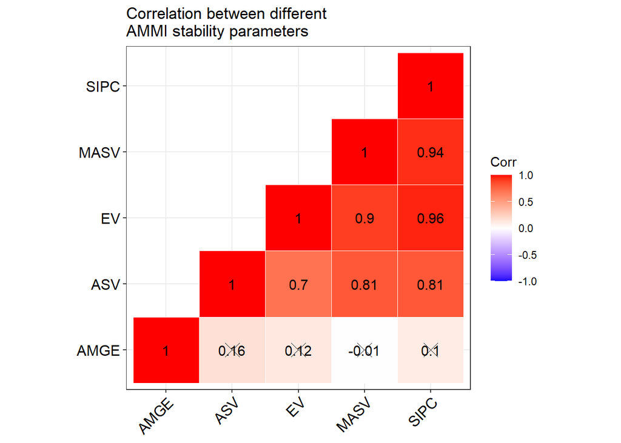

```
$`SSI Correlogram`
```

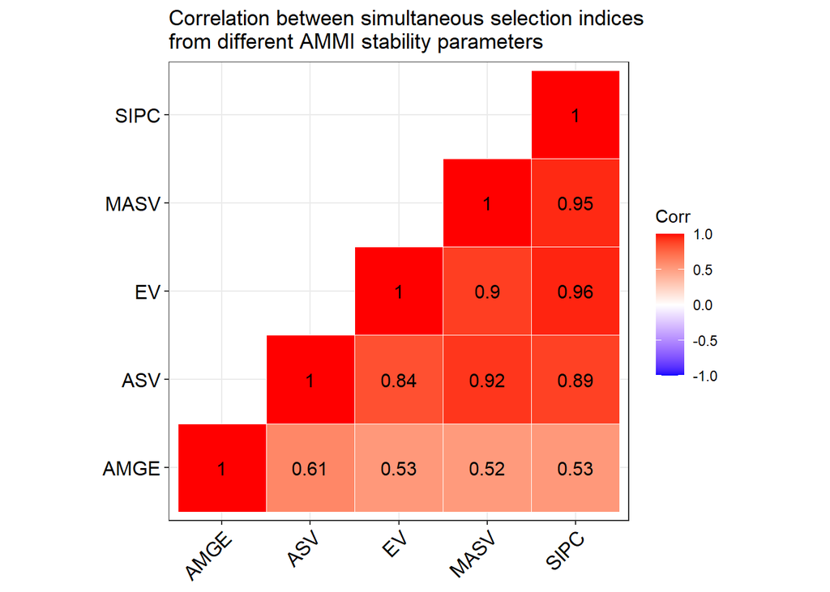

```
$`SP and SSI Correlogram`
```

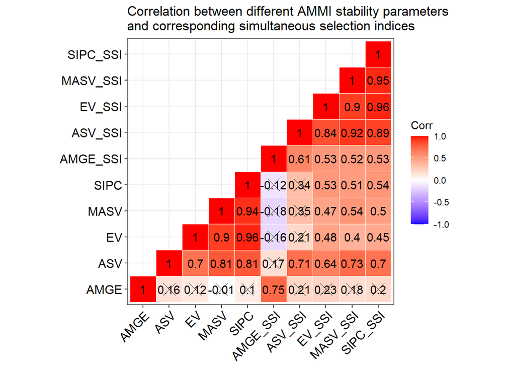

```
$`SP Slopegraph`
```

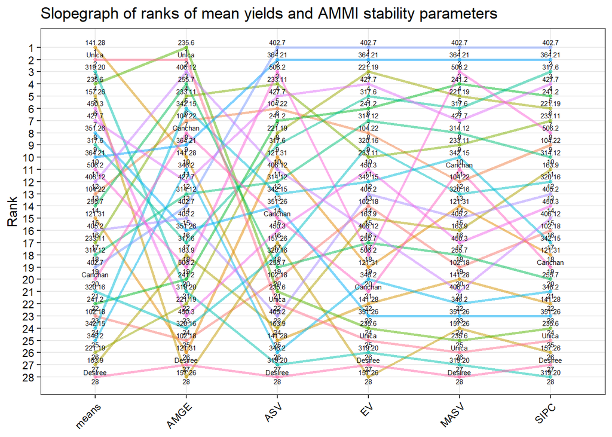

```
$`SSI Slopegraph`
```

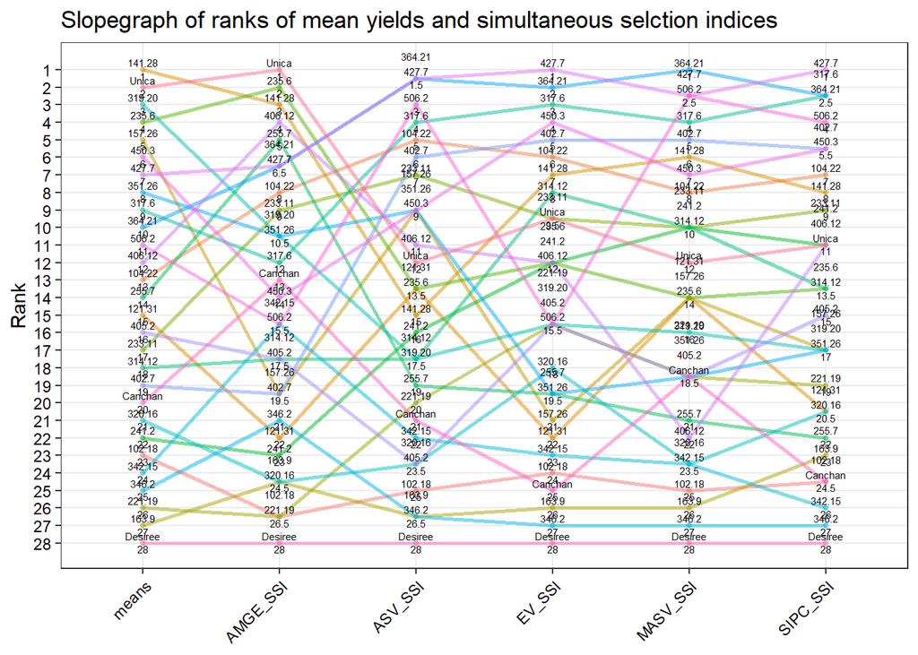

```
$`SP Heatmap`
```

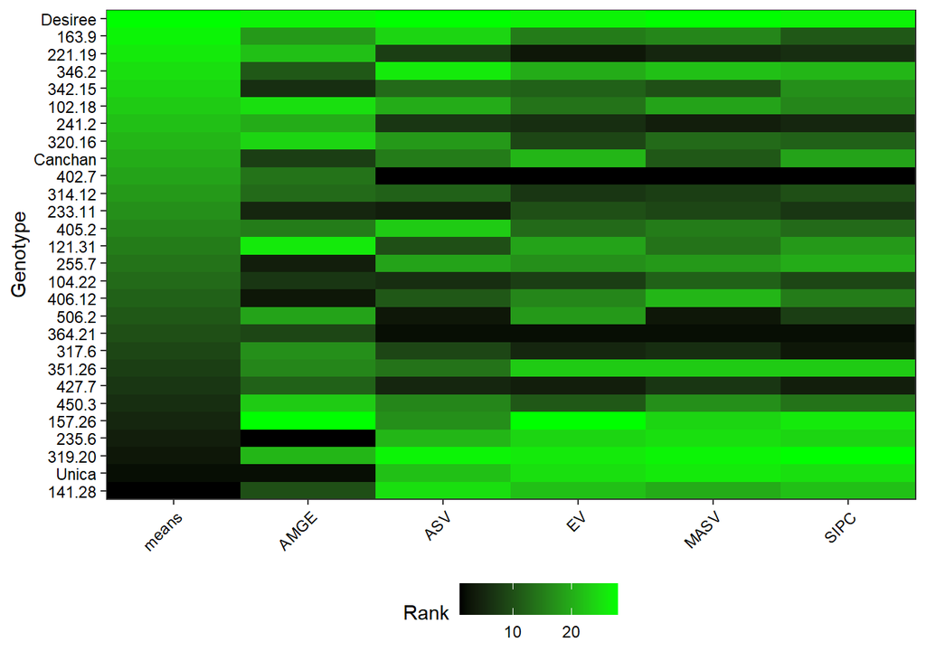

```
$`SSI Heatmap`
```

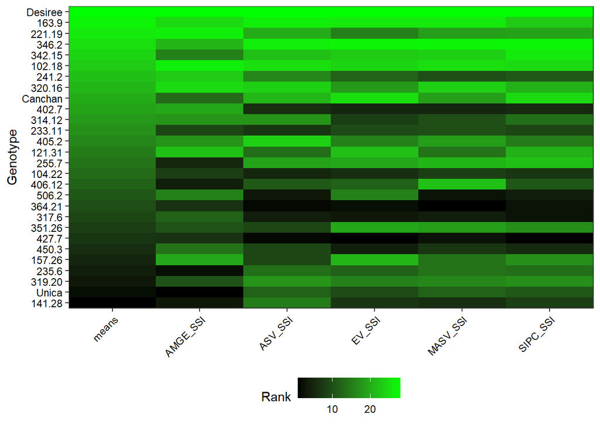

## Citing `ammistability`

```
  Ajay, B. C., Aravind, J., and Abdul Fiyaz, R. (2019). ammistability: R package for ranking genotypes based on stability
  parameters derived from AMMI model. Indian Journal of Genetics and Plant Breeding (The), 79(2), 460-466.
  https://www.isgpb.org/article/ammistability-r-package-for-ranking-genotypes-based-on-stability-parameters-derived-from-ammi-model

  Ajay, B. C., Aravind, J., and Abdul Fiyaz, R. ().  ammistability: Additive Main Effects and Multiplicative Interaction
  Model Stability Parameters. R package version 0.1.4, https://ajaygpb.github.io/ammistability/,
  https://CRAN.R-project.org/package=ammistability.

This free and open-source software implements academic research by the authors and co-workers. If you use it, please
support the project by citing the package.

To see these entries in BibTeX format, use 'print(<citation>, bibtex=TRUE)', 'toBibtex(.)', or set
'options(citation.bibtex.max=999)'.
```

```
R Under development (unstable) (2023-04-28 r84338 ucrt)
Platform: x86_64-w64-mingw32/x64 (64-bit)
Running under: Windows 10 x64 (build 19045)

Matrix products: default


locale:
[1] LC_COLLATE=English_India.utf8  LC_CTYPE=English_India.utf8    LC_MONETARY=English_India.utf8 LC_NUMERIC=C
[5] LC_TIME=English_India.utf8

time zone: Asia/Calcutta
tzcode source: internal

attached base packages:
[1] stats     graphics  grDevices utils     datasets  methods   base

other attached packages:
[1] agricolae_1.3-5     ammistability_0.1.4 kableExtra_1.3.4    RCurl_1.98-1.12     cffr_0.5.0

loaded via a namespace (and not attached):
 [1] tidyselect_1.2.0  viridisLite_0.4.2 dplyr_1.1.2       farver_2.1.1      bitops_1.0-7      fastmap_1.1.1     combinat_0.0-8
 [8] mathjaxr_1.6-0    promises_1.2.0.1  XML_3.99-0.14     labelled_2.11.0   digest_0.6.31     mime_0.12         lifecycle_1.0.3
[15] cluster_2.1.4     klaR_1.7-2        ellipsis_0.3.2    magrittr_2.0.3    compiler_4.4.0    rlang_1.1.0       sass_0.4.6
[22] tools_4.4.0       utf8_1.2.3        yaml_2.3.7        knitr_1.42        labeling_0.4.2    htmlwidgets_1.6.2 curl_5.0.0
[29] plyr_1.8.8        xml2_1.3.4        pkgload_1.3.2     miniUI_0.1.1.1    withr_2.5.0       grid_4.4.0        fansi_1.0.4
[36] AlgDesign_1.2.1   xtable_1.8-4      colorspace_2.1-0  ggplot2_3.4.2     scales_1.2.1      MASS_7.3-59       tinytex_0.45
[43] cli_3.6.1         rmarkdown_2.21    generics_0.1.3    rstudioapi_0.14   httr_1.4.6        reshape2_1.4.4    ggcorrplot_0.1.4
[50] cachem_1.0.8      pander_0.6.5      stringr_1.5.0     rvest_1.0.3       parallel_4.4.0    vctrs_0.6.2       webshot_0.5.4
[57] jsonlite_1.8.4    hms_1.1.3         systemfonts_1.0.4 jquerylib_0.1.4   glue_1.6.2        stringi_1.7.12    rJava_1.0-6
[64] gtable_0.3.3      questionr_0.7.8   later_1.3.0       munsell_0.5.0     tibble_3.2.1      pillar_1.9.0      htmltools_0.5.5
[71] R6_2.5.1          Rdpack_2.4        evaluate_0.21     shiny_1.7.4       lattice_0.21-8    haven_2.5.2       highr_0.10
[78] rbibutils_2.2.13  httpuv_1.6.9      bslib_0.4.2       Rcpp_1.0.10       svglite_2.1.1     nlme_3.1-162      xfun_0.39
[85] forcats_1.0.0     pkgconfig_2.0.3
```

## References

Ajay, B. C., Aravind, J., Abdul Fiyaz, R., Bera, S. K., Kumar, N., Gangadhar, K., et al. (2018). Modified AMMI Stability Index (MASI) for stability analysis. *ICAR-DGR Newsletter* 18, 4–5.

Ajay, B. C., Aravind, J., and Fiyaz, R. A. (2019a). ammistability: R package for ranking genotypes based on stability parameters derived from AMMI model. *Indian Journal of Genetics and Plant Breeding (The)* 79, 460–466. doi:10.31742/IJGPB.79.2.10.

Ajay, B. C., Aravind, J., Fiyaz, R. A., Kumar, N., Lal, C., Gangadhar, K., et al. (2019b). Rectification of modified AMMI stability value (MASV). *Indian Journal of Genetics and Plant Breeding (The)* 79, 726–731. Available at: https://www.isgpb.org/article/rectification-of-modified-ammi-stability-value-masv.

Annicchiarico, P. (1997). Joint regression vs AMMI analysis of genotype-environment interactions for cereals in Italy. *Euphytica* 94, 53–62. doi:10.1023/A:1002954824178.

Bajpai, P. K., and Prabhakaran, V. T. (2000). A new procedure of simultaneous selection for high yielding and stable crop genotypes. *Indian Journal of Genetics & Plant Breeding* 60, 141–146.

Farshadfar, E. (2008). Incorporation of AMMI stability value and grain yield in a single non-parametric index (GSI) in bread wheat. *Pakistan Journal of biological sciences* 11, 1791. doi:10.3923/pjbs.2008.1791.1796.

Farshadfar, E., Mahmodi, N., and Yaghotipoor, A. (2011). AMMI stability value and simultaneous estimation of yield and yield stability in bread wheat (*Triticum aestivum* L.). *Australian Journal of Crop Science* 5, 1837–1844.

Gauch, H. G. (1988). Model selection and validation for yield trials with interaction. *Biometrics* 44, 705–715. doi:10.2307/2531585.

Gauch, H. G. (1992). *Statistical Analysis of Regional Yield Trials: AMMI Analysis of Factorial Designs*. Amsterdam ; New York: Elsevier.

Jambhulkar, N. N., Bose, L. K., Pande, K., and Singh, O. N. (2015). Genotype by environment interaction and stability analysis in rice genotypes. *Ecology, Environment and Conservation* 21, 1427–1430. Available at: http://www.envirobiotechjournals.com/article_abstract.php?aid=6346&iid=200&jid=3.

Jambhulkar, N. N., Bose, L. K., and Singh, O. N. (2014). “AMMI stability index for stability analysis,” in *CRRI Newsletter, January-March 2014*, ed. T. Mohapatra (Cuttack, Orissa: Central Rice Research Institute), 15. Available at: https://crri.icar.gov.in/crnl_jan_mar_14_web.pdf.

Jambhulkar, N. N., Rath, N. C., Bose, L. K., Subudhi, H., Biswajit, M., Lipi, D., et al. (2017). Stability analysis for grain yield in rice in demonstrations conducted during rabi season in India. *Oryza* 54, 236–240. doi:10.5958/2249-5266.2017.00030.3.

Purchase, J. L. (1997). Parametric analysis to describe genotype × environment interaction and yield stability in winter wheat. Available at: https://scholar.ufs.ac.za:8080/xmlui/handle/11660/1966.

Purchase, J. L., Hatting, H., and Deventer, C. S. van (1999). “The use of the AMMI model and AMMI stability value to describe genotype x environment interaction and yield stability in winter wheat (*Triticum aestivum* L.),” in *Proceedings of the Tenth Regional Wheat Workshop for Eastern, Central and Southern Africa, 14-18 September 1998* (South Africa: University of Stellenbosch).

Purchase, J. L., Hatting, H., and Deventer, C. S. van (2000). Genotype × environment interaction of winter wheat (*Triticum aestivum* L.) In South Africa: II. Stability analysis of yield performance. *South African Journal of Plant and Soil* 17, 101–107. doi:10.1080/02571862.2000.10634878.

Raju, B. M. K. (2002). A study on AMMI model and its biplots. *Journal of the Indian Society of Agricultural Statistics* 55, 297–322.

Rao, A. R., and Prabhakaran, V. T. (2005). Use of AMMI in simultaneous selection of genotypes for yield and stability. *Journal of the Indian Society of Agricultural Statistics* 59, 76–82.

Sneller, C. H., Kilgore-Norquest, L., and Dombek, D. (1997). Repeatability of yield stability statistics in soybean. *Crop Science* 37, 383–390. doi:10.2135/cropsci1997.0011183X003700020013x.

Wricke, G. (1962). On a method of understanding the biological diversity in field research. *Zeitschrift für Pflanzenzüchtung* 47, 92–146.

Zali, H., Farshadfar, E., Sabaghpour, S. H., and Karimizadeh, R. (2012). Evaluation of genotype × environment interaction in chickpea using measures of stability from AMMI model. *Annals of Biological Research* 3, 3126–3136.

Zhang, Z., Lu, C., and Xiang, Z. (1998). Analysis of variety stability based on AMMI model. *Acta Agronomica Sinica* 24, 304–309. Available at: https://zwxb.chinacrops.org/EN/Y1998/V24/I03/304.

Zobel, R. W. (1994). “Stress resistance and root systems,” in *Proceedings of the Workshop on Adaptation of Plants to Soil Stress. 1-4 August, 1993. INTSORMIL Publication 94-2* (Institute of Agriculture; Natural Resources, University of Nebraska-Lincoln), 80–99.